# Graphics & Cognition

How Do We Test Statistical Visualizations?

Susan Vanderplas

October 12, 2026

# A Quick Cognition Primer

[figure not shown]

## Attention

- Focused or Divided?
  - Divided: multiple input streams
  - Focused: single input stream
- Attention shifts with gaze
- Extra information may not be stored or remembered

[figure not shown]

## Introspection

When reading a chart, what do you focus on

**first**?

**second**?

**third**?

## Introspection

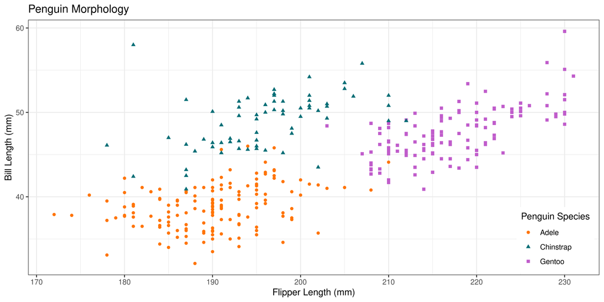

## Introspection

When reading a chart, what do you focus on

**first**?

**second**?

**third**?

Most features require **attention**

We can observe these features with **introspection**

**Preattentive** features must be examined in other ways

## Long Term Memory

[figure not shown]

Long Term Memory Information Retrieval

## Long Term Memory

- unlimited storage capacity (theoretically)
- maintained for long periods
- two types:
  - declarative/explicit - consciously accessed
  - non-declarative/implicit - procedural memories

## Working Memory

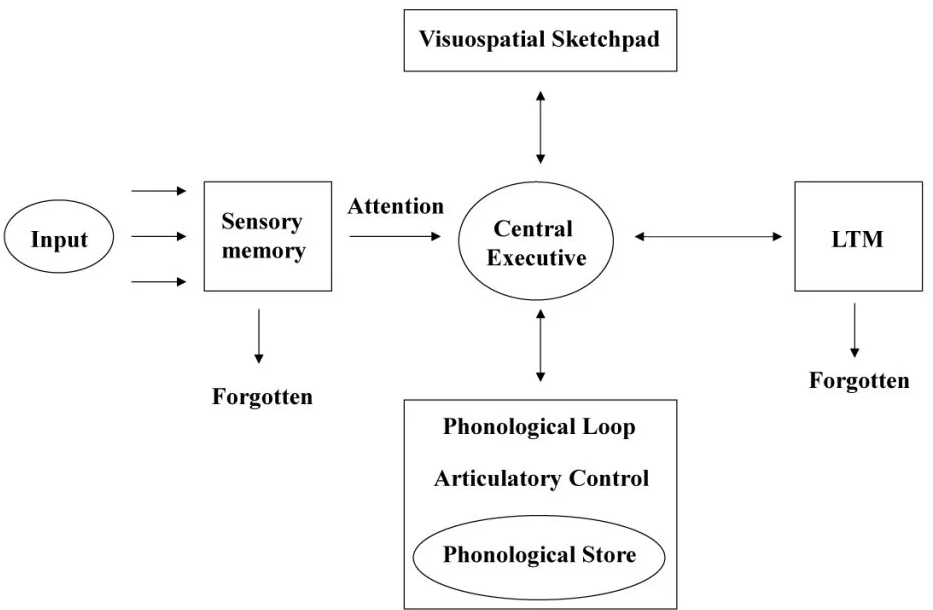

[Image Source](https://www.simplypsychology.org/working-memory.html)

- Proposed by Baddeley and Hitch (1974)
- Limited capacity
- Components are thought to be mostly independent

# Application to Charts

## Perception

- Sensory input
- Recognition of type of chart
- Takes place very quickly

[figure not shown]

## Gestalt Grouping

- Gestalt heuristics used to group points into clusters/trends

[figure not shown]

## Integration with Domain Knowledge

- Begin to assign meaning
- Data + Axis titles + Chart title
- Retrieve info from long term memory $\rightarrow$ working memory

[figure not shown]

## Integration with Domain Knowledge

Domain knowledge includes:

- Typical chart structure  
  (e.g. y-axis increases from bottom to top)
- Chart conventions  
  use of filled vs. empty space
- Knowledge of relationships, events, etc.

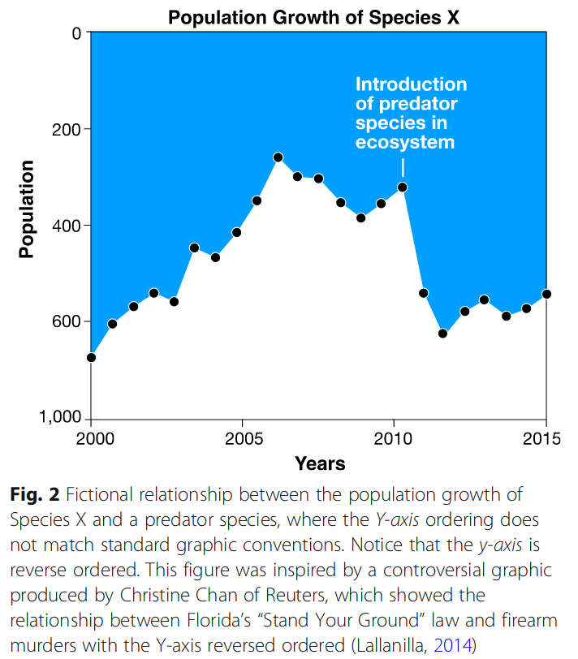

Figure from Padilla et al. *Cognitive Research: Principles and Implications* (2018) 3:29

## Storytelling

- Relationships $\rightarrow$ meaning
- Fit visual statistics
- Test features against a working hypothesis

[figure not shown]

## Inference

- Numerical estimation  
  (with uncertainty)
- Visual search, followed by estimation, calculation, and inference.

[figure not shown]

## Prediction and Application

- Moving beyond the data to **interpret** and apply meaning
- Draw conclusions
- Make predictions for the future

[figure not shown]

# Testing Graphical Perception

## Testing Accuracy

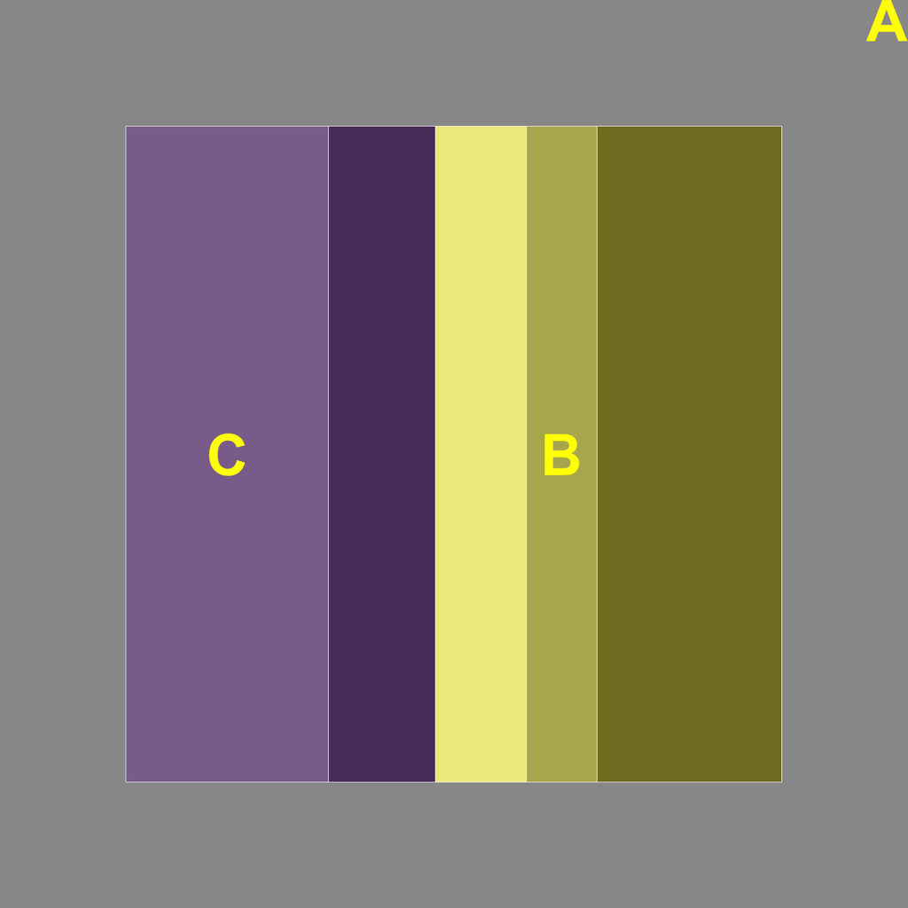

- What proportion of the plot is
  - A? **48**%
  - B? **5.5**%
  - C? **16**%
- The most accurate chart  
  (by this measure) is a … **table**???

From [VanderPlas, Susan, Goluch C. Ryan, and Heike Hofmann. 2019. “Framed! Reproducing and Revisiting 150-Year-Old Charts.” Journal of Computational and Graphical Statistics 28(3):620–34.](https://doi.org/10.1080/10618600.2018.1562937)

## Visual Hypothesis Testing

- Which plot(s) are not like the others?
- Inference: which feature(s) are relevant?
- Hypothesis testing:  
  1/20 = 0.05

[figure not shown]

From [VanderPlas, Susan, and Heike Hofmann. 2017. “Clusters Beat Trend⁉ Testing Feature Hierarchy in Statistical Graphics.” Journal of Computational and Graphical Statistics 26(2):231–42.](https://doi.org/10.1080/10618600.2016.1209116)

## Direct Annotation

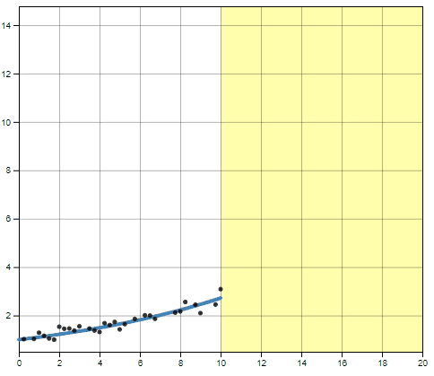

- Removes numerical calculation issues
- Less intimidating?
- Requires motor control  
  (or patience)

From [Robinson, Emily A., Reka Howard, and Susan VanderPlas. 2023. “‘You Draw It’: Implementation of Visually Fitted Trends with R2d3.” Journal of Data Science 21(2):281–94.](https://doi.org/10.6339/22-JDS1083) and  
[Robinson, Emily A., Reka Howard, and Susan VanderPlas. 2022. “Eye Fitting Straight Lines in the Modern Era.” Journal of Computational and Graphical Statistics 0(0):1–8.](https://doi.org/10.1080/10618600.2022.2140668)

## Can We Test Graphics Better?

[figure not shown]